# The Metabolic Capability and Phylogenetic Diversity of Mono Lake During a Bloom of Picocystis strain ML

# Introduction

First, I process the raw data are processed using QIIME and UPARSE (https://www.drive5.com/uparse/). I usually run the below outside of a Markdown notebook, but for clarity and simplicity I’ve included them below. Depending on your computer you may have problems running more memory intensive steps, e.g. taxonomy assignment and sequence alignment. For QIIME and UPARSE we used a 16 core (2x 8 core Intel Xeon) / 128 GB RAM workstation, running Ubuntu 16.10.

You will need the initial mapping file for QC, as well as the mapping (Both included in the github repository as well as supplemental data) file to recreate this analysis.

Software used: - QIIME 1.9.1 (http://qiime.org/) - UPARSE (https://www.drive5.com/uparse/) - PEAR (https://bioconda.github.io/recipes/pear/README.html) - All dependencies for the above software

# Initial Pre-Processing

I keep QIIME in a virtual environment to keep everyone else happy on the workstation

`bash`bash source activate qiime1

`bash`bash pear -f seq/ngs-9y64x548t1_S1_L001_R1_001.fastq -r seq/ngs-9y64x548t1_S1_L001_R2_001.fastq -o seq/ML -p 0.001 -v 50 -m 450 -n 250 -y 500m -j 16

`bash`bash cat seq/ML.unassembled.* > seq/ML.Un.fastq

extract_barcodes.py -a -m map.txt -f seq/ML.assembled.fastq -a -m map.txt -l 12 -o seq/PrepJoin/

extract_barcodes.py -f seq/ML.Un.fastq -l 12 -o seq/PrepUn/

`bash`bash split_libraries_fastq.py –barcode_type 12 -i seq/PrepJoin/reads.fastq -b seq/PrepJoin/barcodes.fastq -m map.txt –phred_quality_threshold 0 –store_demultiplexed_fastq -o seq/SlOutJoin/

split_libraries_fastq.py –barcode_type 12 -i seq/PrepUn/reads.fastq -b seq/PrepUn/barcodes.fastq -m map.txt –phred_quality_threshold 0 –store_demultiplexed_fastq -o seq/SlOutUn/

# OTU Clustering and Taxonomy Assignment

`bash`bash mkdir UPARSE mkdir UPARSE/Join/ usearch64 -fastq_stats seq/SlOutJoin/seqs.fastq -log UPARSE/Join/seqs.stats.log usearch64 -fastq_filter seq/SlOutJoin/seqs.fastq -fastaout UPARSE/Join/seqs.filtered.fasta -fastq_maxee 1 -threads 16 usearch64 -derep_fulllength UPARSE/Join/seqs.filtered.fasta -fastaout UPARSE/Join/seqs.filtered.derep.fasta -sizeout -threads 16 usearch64 -sortbysize UPARSE/Join/seqs.filtered.derep.fasta -minsize 3 -fastaout UPARSE/Join/seqs.filtered.derep.mc2.fasta usearch64 -cluster_otus UPARSE/Join/seqs.filtered.derep.mc2.fasta -otus UPARSE/Join/seqs.filtered.derep.mc2.repset.fasta usearch64 -uchime_ref UPARSE/Join/seqs.filtered.derep.mc2.repset.fasta -db /media/analyses/DB/gold.fasta -strand plus -nonchimeras UPARSE/Join/seqs.filtered.derep.mc2.repset.nochimeras.fasta -threads 16 fasta_number.py UPARSE/Join/seqs.filtered.derep.mc2.repset.nochimeras.fasta OTU_ > UPARSE/Join/seqs.filtered.derep.mc2.repset.nochimeras.OTUs.fasta cp UPARSE/Join/seqs.filtered.derep.mc2.repset.nochimeras.OTUs.fasta UPARSE/Join/RepSet.fna usearch64 -usearch_global seq/SlOutJoin/seqs.fna -db UPARSE/Join/seqs.filtered.derep.mc2.repset.nochimeras.OTUs.fasta -strand plus -id 0.97 -uc UPARSE/Join/otu.map.uc -threads 16 python /home/lab/.conda/envs/qiime1/bin/uc2otutab.py UPARSE/Join/otu.map.uc > UPARSE/Join/seqs.filtered.derep.mc2.repset.nochimeras.OTU-table.txt assign_taxonomy.py -m mothur -t /media/analyses/DB/silva.nr_v128.tax -r /media/analyses/DB/silva.nr_v128.align -o UPARSE/Join/mothur_taxonomy/ -i UPARSE/Join/RepSet.fna biom convert –table-type=table -i UPARSE/Join/seqs.filtered.derep.mc2.repset.nochimeras.OTU-table.txt -o UPARSE/Join/UPARSE.biom –to-json biom add-metadata –sc-separated taxonomy –observation-header OTUID,taxonomy –observation-metadata-fp UPARSE/Join/mothur_taxonomy/RepSet_tax_assignments.txt -i UPARSE/Join/UPARSE.biom -o UPARSE/Join/UPARSE_w_tax.biom biom add-metadata -i UPARSE/Join/UPARSE_w_tax.biom -o UPARSE/Join/UPARSE.w_md.biom –sample-metadata-fp map.txt filter_samples_from_otu_table.py -m map.txt -s ‘SampleType:Control’ -n 200 -o UPARSE/Join/Control.biom -i UPARSE/Join/UPARSE.w_md.biom compute_core_microbiome.py –min_fraction_for_core 0.25 –max_fraction_for_core 0.95 -i UPARSE/Join/Control.biom -o UPARSE/Join/ControlCore/

`bash`bash mkdir UPARSE/Un/ usearch64 -fastq_stats seq/SlOutUn/seqs.fastq -log UPARSE/Un/seqs.stats.log usearch64 -fastq_filter seq/SlOutUn/seqs.fastq -fastaout UPARSE/Un/seqs.filtered.fasta -fastq_maxee 1 -threads 16 usearch64 -derep_fulllength UPARSE/Un/seqs.filtered.fasta -fastaout UPARSE/Un/seqs.filtered.derep.fasta -sizeout -threads 16 usearch64 -sortbysize UPARSE/Un/seqs.filtered.derep.fasta -minsize 3 -fastaout UPARSE/Un/seqs.filtered.derep.mc2.fasta usearch64 -cluster_otus UPARSE/Un/seqs.filtered.derep.mc2.fasta -otus UPARSE/Un/seqs.filtered.derep.mc2.repset.fasta usearch64 -uchime_ref UPARSE/Un/seqs.filtered.derep.mc2.repset.fasta -db /media/analyses/DB/gold.fasta -strand plus -nonchimeras UPARSE/Un/seqs.filtered.derep.mc2.repset.nochimeras.fasta -threads 16 fasta_number.py UPARSE/Un/seqs.filtered.derep.mc2.repset.nochimeras.fasta OTU_ > UPARSE/Un/seqs.filtered.derep.mc2.repset.nochimeras.OTUs.fasta cp UPARSE/Un/seqs.filtered.derep.mc2.repset.nochimeras.OTUs.fasta UPARSE/Un/RepSet.fna usearch64 -usearch_global seq/SlOutUn/seqs.fna -db UPARSE/Un/seqs.filtered.derep.mc2.repset.nochimeras.OTUs.fasta -strand plus -id 0.97 -uc UPARSE/Un/otu.map.uc -threads 16 python /home/lab/.conda/envs/qiime1/bin/uc2otutab.py UPARSE/Un/otu.map.uc > UPARSE/Un/seqs.filtered.derep.mc2.repset.nochimeras.OTU-table.txt assign_taxonomy.py -m mothur -t /media/analyses/DB/silva.nr_v128.tax -r /media/analyses/DB/silva.nr_v128.align -o UPARSE/Un/mothur_taxonomy/ -i UPARSE/Un/RepSet.fna biom convert –table-type=table -i UPARSE/Un/seqs.filtered.derep.mc2.repset.nochimeras.OTU-table.txt -o UPARSE/Un/UPARSE.biom –to-json biom add-metadata –sc-separated taxonomy –observation-header OTUID,taxonomy –observation-metadata-fp UPARSE/Un/mothur_taxonomy/RepSet_tax_assignments.txt -i UPARSE/Un/UPARSE.biom -o UPARSE/Un/UPARSE_w_tax.biom biom add-metadata -i UPARSE/Un/UPARSE_w_tax.biom -o UPARSE/Un/UPARSE.w_md.biom –sample-metadata-fp map.txt filter_samples_from_otu_table.py -m map.txt -s ‘SampleType:Control’ -n 500 -o UPARSE/Un/Control.biom -i UPARSE/Un/UPARSE.w_md.biom compute_core_microbiome.py –min_fraction_for_core 0.25 –max_fraction_for_core 0.75 -i UPARSE/Un/Control.biom -o UPARSE/Un/ControlCore/

# Contamination Screening

`bash`bash filter_otus_from_otu_table.py -e UPARSE/Join/ControlCore/core_otus_95.txt -s 3 -n 1 -i UPARSE/Join/UPARSE_w_tax.biom -o UPARSE/Join/PostControlFilter.biom filter_samples_from_otu_table.py –sample_id_fp AnalysisMap.txt -n 500 -i UPARSE/Join/PostControlFilter.biom -o UPARSE/Join/Analysis.biom filter_taxa_from_otu_table.py -n Eukaryota -i UPARSE/Join/Analysis.biom -o UPARSE/Analysis_BacArc.biom

filter_samples_from_otu_table.py –sample_id_fp AnalysisMap.txt -n 500 -i UPARSE/Un/UPARSE_w_tax.biom -o UPARSE/Un/Analysis.biom filter_taxa_from_otu_table.py -p Eukaryota -i UPARSE/Un/Analysis.biom -o UPARSE/Analysis_Euk.biom

Before moving on, I want to generate some summaries to see how many sequences I have left overall, and how many SVs were retained/removed after filtering.

`bash`bash biom summarize-table -i UPARSE/Join/UPARSE_w_tax.biom -o Join_all_w_tax_summary.txt biom summarize-table -i UPARSE/Join/PostControlFilter.biom -o Join_PostControlFilter_summary.txt biom summarize-table -i UPARSE/Join/Analysis.biom -o Join_Analysis_summary.txt biom summarize-table -i UPARSE/Analysis_BacArc.biom -o Analysis_BacArc_summary.txt

biom summarize-table -i UPARSE/Un/UPARSE_w_tax.biom -o Un_all_w_tax_summary.txt biom summarize-table -i UPARSE/Un/Analysis.biom -o Un_Analysis_summary.txt biom summarize-table -i UPARSE/Analysis_Euk.biom -o Analysis_Euk_summary.txt

What does this look like?

Unfiltered BIOM, post clustering: 601 OTUs, 724155 Sequences Post contaminant filtration: 569 OTUs, 634641 Sequences Post removal of control samples: 569 OTUs, 615813 Sequences Excluding Eukaryotic Sequence: 566 OTUs, 615518 Sequences

Counts/sample summary: Min: 1735.0 Max: 25105.0 Median: 7987.500 Mean: 8230.212 Std. dev.: 3413.020

Unfiltered BIOM, post clustering: 317 OTUs, 82062 Sequences Post removal of control samples: 317 OTUs, 81281 Sequences Excluding Bacterial and Archaeal Sequence: 265 OTUs, 79430 Sequences

Counts/sample summary: Min: 480.0 Max: 3333.0 Median: 1338.500 Mean: 1527.500 Std. dev.: 742.038

Next, I’ll add sample metadata to each file, and then convert my two analysis BIOM files to JSON format for use in Phyloseq/R

`bash`bash biom add-metadata -i UPARSE/Analysis_BacArc.biom -o UPARSE/Analysis_BacArc.w_md.biom –sample-metadata-fp R_metadata.txt biom convert -i UPARSE/Analysis_BacArc.w_md.biom -o UPARSE/BacArc.w_md.json.biom –table-type=table –to-json

biom add-metadata -i UPARSE/Analysis_Euk.biom -o UPARSE/Analysis_Euk.w_md.biom –sample-metadata-fp R_metadata.txt biom convert -i UPARSE/Analysis_Euk.w_md.biom -o UPARSE/Euk.w_md.json.biom –table-type=table –to-json

# Tree Building and Final BIOM File Generation

Last step before moving into R. Generation of phylogenetic trees for use in Phyloseq, as needed.

`bash`bash filter_fasta.py -b UPARSE/Analysis_BacArc.biom -f UPARSE/Join/RepSet.fna -o UPARSE/Analysis_BacArc.seqs.fa

filter_fasta.py -b UPARSE/Analysis_Euk.biom -f UPARSE/Un/RepSet.fna -o UPARSE/Analysis_Euk.seqs.fa

`bash`bash align_seqs.py -i UPARSE/Analysis_BacArc.seqs.fa -t /media/analyses/DB/SILVA_128_QIIME_release/rep_set_aligned/97/97_otus_aligned.fasta -o UPARSE/Analysis_BacArc_RepSet_Aligned/ align_seqs.py -i UPARSE/Analysis_Euk.seqs.fa -t /media/analyses/DB/SILVA_128_QIIME_release/rep_set_aligned/97/97_otus_aligned.fasta -o UPARSE/Analysis_Euk_RepSet_Aligned/

filter_alignment.py -i UPARSE/Analysis_BacArc_RepSet_Aligned/Analysis_BacArc.seqs_aligned.fasta -o UPARSE/Analysis_BacArc_RepSet_Aligned/ -e 0.001 filter_alignment.py -i UPARSE/Analysis_Euk_RepSet_Aligned/Analysis_Euk.seqs_aligned.fasta -o UPARSE/Analysis_Euk_RepSet_Aligned/ -e 0.001

make_phylogeny.py -i UPARSE/Analysis_BacArc_RepSet_Aligned/Analysis_BacArc.seqs_aligned_pfiltered.fasta -o UPARSE/BacArc.tre make_phylogeny.py -i UPARSE/Analysis_Euk_RepSet_Aligned/Analysis_Euk.seqs_aligned_pfiltered.fasta -o UPARSE/Euk.tre

Analysis in R

=====

Onto R. This can be run on (almost) any desktop/laptop without issue. In my case, I downloaded the above output files (.biom, .tre. and .fa) from my workstation onto my laptop to run the below.

Load Needed Libraries

`r`r library(phyloseq) library(ampvis) library(cowplot)

First, I’m going to import the my BIOM files, and format the taxonomy string to behave with Phyloseq and AmpVis.

Next, I’ll subset my Phyloseq objects to exclude incubation samples. You can see the results of the incubations in supplementary data.

`r`r ML.wChloroplast.BacArc <- subset_samples(ML.BacArc, SampleName %in% c(.SurfaceWater, .2m, .10m, .20m,.25m, .Sed.10m, .Water, .RiverWater, .RiverWater, .RiverWater, .RiverWater)) ML.RA.wChloroplast.BacArc <- transform_sample_counts(ML.wChloroplast.BacArc, function(x) x / sum(x) * 100)

As a small step, chloroplast and mitochondial sequence need to be removed from the Bacterial/Archaeal phyloseq object- we’ll see them in the Eukaryotic dataset (Or at least the owners of those mitochondria and chloroplast…)

`r`r ML.BacArc.Filter <- ML.BacArc %>% subset_taxa( Family != & Class != )

I’m going to convert to relative abundances for some chart types. RA standing for “Relative Abundance”

`r`r ML.RA.BacArc <- transform_sample_counts(ML.BacArc.Filter, function(x) x / sum(x) * 100) ML.RA.Euk <- transform_sample_counts(ML.Euk, function(x) x / sum(x) * 100)

Next, I’m going to rarefy the table for later use. I set the rarefaction depth to include all samples.

`r`r ML.Rare.BacArc <- rarefy_even_depth(ML.BacArc.Filter, sample.size = 1500, rngseed = 712)

```
`set.seed(712)` was used to initialize repeatable random subsampling.
Please record this for your records so others can reproduce.
Try `set.seed(712); .Random.seed` for the full vector
...
6OTUs were removed because they are no longer
present in any sample after random subsampling

...
```

`r`r ML.Rare.Euk <- rarefy_even_depth(ML.Euk, sample.size = 400, rngseed = 712)

```
`set.seed(712)` was used to initialize repeatable random subsampling.
Please record this for your records so others can reproduce.
Try `set.seed(712); .Random.seed` for the full vector
...
6OTUs were removed because they are no longer
present in any sample after random subsampling

...
```

`r`r ML.RA.WaterOnly <- subset_samples(ML.RA.BacArc, SampleName %in% c(.SurfaceWater, .2m, .10m, .20m,.25m)) ML.And.Rivers.BA.RA <- subset_samples(ML.RA.BacArc, SampleName %in% c(.SurfaceWater, .2m, .10m, .20m,.25m, .Sed.10m, .Water, .RiverWater, .RiverWater, .RiverWater, .RiverWater)) ML.And.Rivers.Euk.RA <- subset_samples(ML.RA.Euk, SampleName %in% c(.SurfaceWater, .2m, .10m, .20m,.25m, .Sed.10m, .Water, .RiverWater, .RiverWater, .RiverWater, .RiverWater))

I’m going to define a color set to use throughout the script.

First up, figure 3- a heatmap of the top 25 taxa of either the Bacteria and Archaea (A), or the Eukarya (B) across the sampled depth transect at Mono, or the nearby streams and well.

```
Transformation introduced infinite values in discrete y-axisTransformation introduced infinite values in discrete y-axis
```

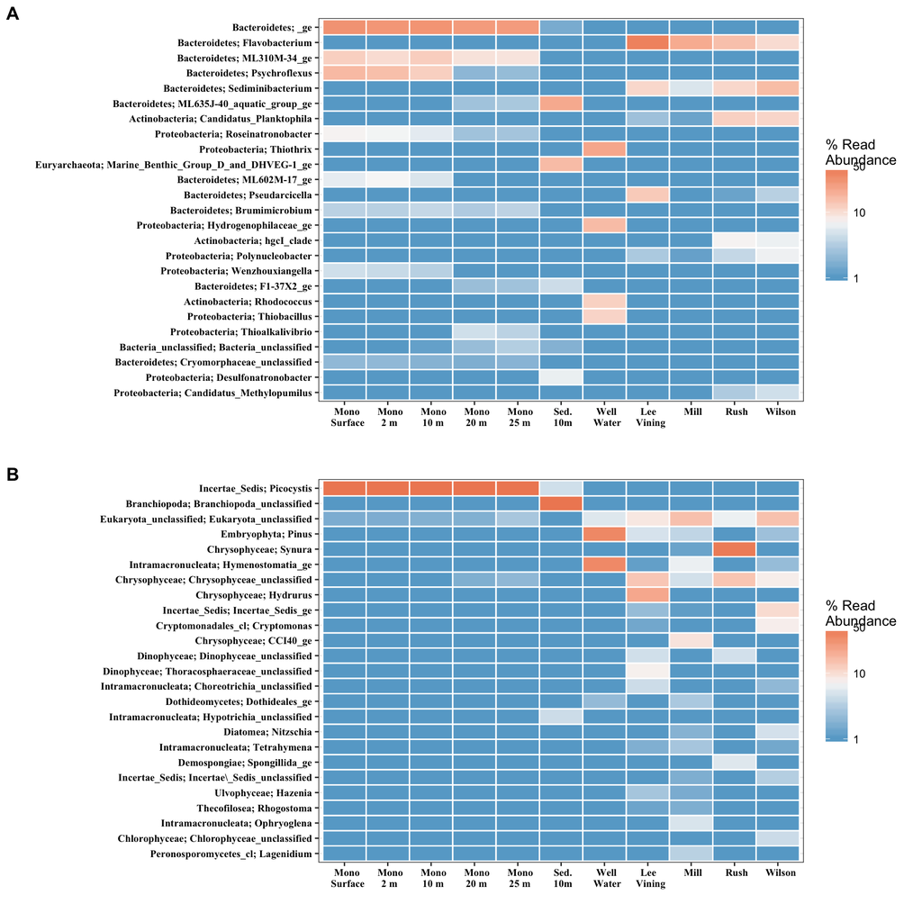

Now, figure 4. Again, I’ll subset my dataset to now only include water samples from 2 to 25 m depth.

`r`r ML.BA.Rare.Transect <- subset_samples(ML.Rare.BacArc, SampleName %in% c(.2m, .10m, .20m,.25m)) ML.Euk.Rare.Transect <- subset_samples(ML.Rare.Euk, SampleName %in% c(.2m, .10m, .20m,.25m))

Figure 4 A) Bacteria/Archaea, and B) Eukarya

`r`r ML.BA.PCA <- ordinate(ML.BA.Rare.Transect, method = , distance = )

```
Randomly assigning root as -- OTU_543 -- in the phylogenetic tree in the data you provided.
```

`r`r ML.BA.PCA <- plot_ordination(ML.BA.Rare.Transect, ML.BA.PCA, color=) Transect.PCA.BA<-ML.BA.PCA + scale_colour_manual(values = ML.cols) + scale_fill_manual(values = ML.cols) + theme(panel.grid.major = element_blank(), panel.grid.minor = element_blank(), panel.background = element_blank(), axis.line = element_line(colour = )) ML.Euk.PCA <- ordinate(ML.Euk.Rare.Transect, method = , distance = )

```
Randomly assigning root as -- OTU_119 -- in the phylogenetic tree in the data you provided.
```

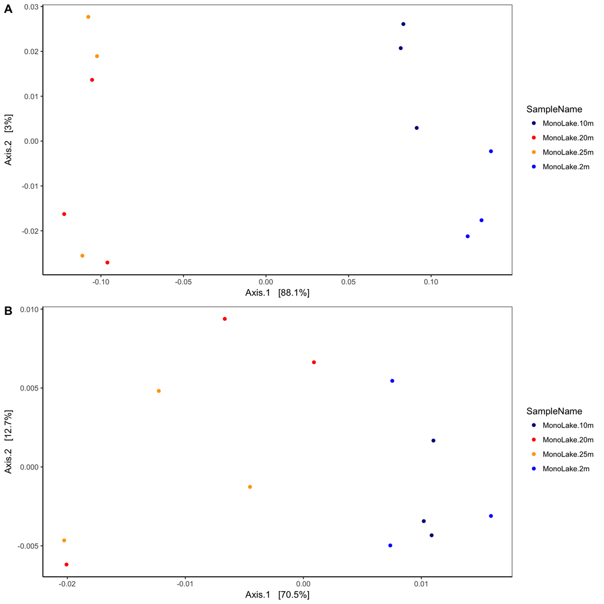

OK, so a clear separation between the deep (Red/Orange) samples and the more shallow (Blue) samples. We’ll confirm by ADONIS in a little bit.

`r`r ML.BA.Rare.Data = as(sample_data(ML.BA.Rare.Transect), .frame) BA.d = phyloseq::distance(ML.BA.Rare.Transect, )

```
Randomly assigning root as -- OTU_141 -- in the phylogenetic tree in the data you provided.
```

`r`r ML.Euk.Rare.Data = as(sample_data(ML.Euk.Rare.Transect), .frame) Euk.d = phyloseq::distance(ML.Euk.Rare.Transect, )

```
Randomly assigning root as -- OTU_192 -- in the phylogenetic tree in the data you provided.
```

`r`r adonis(BA.d ~ SampleName, ML.BA.Rare.Data)

```
Call:
adonis(formula = BA.d ~ SampleName, data = ML.BA.Rare.Data)

Permutation: free
Number of permutations: 999

Terms added sequentially (first to last)

           Df SumsOfSqs  MeanSqs F.Model      R2 Pr(>F)
SampleName  3  0.079328 0.026443  26.417 0.90831  0.002 **
Residuals   8  0.008008 0.001001         0.09169
Total      11  0.087335                  1.00000
---
Signif. codes:
0 ‘***’ 0.001 ‘**’ 0.01 ‘*’ 0.05 ‘.’ 0.1 ‘ ’ 1
```

Overall, highly significant with very high (> 0.90) R2 value.

`r`r adonis(Euk.d ~ SampleName, ML.Euk.Rare.Data)

```
Call:
adonis(formula = Euk.d ~ SampleName, data = ML.Euk.Rare.Data)

Permutation: free
Number of permutations: 999

Terms added sequentially (first to last)

           Df SumsOfSqs    MeanSqs F.Model      R2 Pr(>F)
SampleName  3 0.0028041 0.00093469  4.2684 0.61548  0.017 *
Residuals   8 0.0017518 0.00021898         0.38452
Total      11 0.0045559                    1.00000
---
Signif. codes:
0 ‘***’ 0.001 ‘**’ 0.01 ‘*’ 0.05 ‘.’ 0.1 ‘ ’ 1
```

The Eukarya produce a significant, but much weaker difference between depths. This is likely driven by the high relative abundance of an OTU most closely related to Picocystis sp.

——SUPPLEMENTAL——

Let’s see what the samples look like with chloroplast included

`r`r amp_heatmap(data = ML.RA.wChloroplast.BacArc, tax.aggregate = , tax.add = , group = c(), tax.show = 25, tax.empty = , plot.numbers = T, plot.breaks = c(1.0,10.0,50.0), max.abundance = 50, min.abundance = 1, order.x = c(.SurfaceWater, .2m, .10m, .20m,.25m, .Sed.10m, .Water, .RiverWater, .RiverWater, .RiverWater, .RiverWater), scale.seq = 100) + scale_x_discrete(labels = c(,2 m,10 m,20 m,25 m,.10m,, , , , )) + theme(axis.text.x = element_text(size =8, color = , hjust = 0.4, angle = 0, family=New Roman, face=)) + theme(axis.text.y = element_text(size =8, color = , angle = 0, family=New Roman, face=))

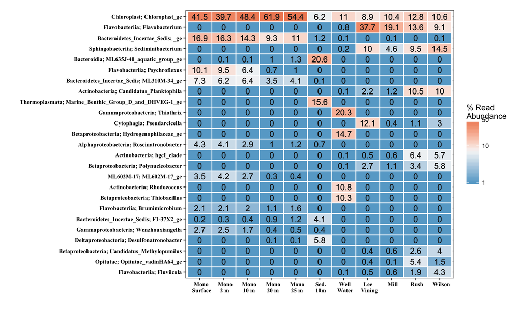

`r`r ML.BA.RA.Incubation <- subset_samples(ML.RA.BacArc, SampleName %in% c(..CC.Zero, .CC.MeOH, .CC.B, .CC.NH4, .CC.No, .CC.G, .2m)) ML.Euk.RA.Incubation <- subset_samples(ML.RA.Euk, SampleName %in% c(..CC.Zero, .CC.MeOH, .CC.B, .CC.NH4, .CC.No, .CC.G, .2m)) ML.BA.Rare.Incubation <- subset_samples(ML.Rare.BacArc, SampleName %in% c(..CC.Zero, .CC.MeOH, .CC.B, .CC.NH4, .CC.No, .CC.G, .2m)) ML.Euk.Rare.Incubation <- subset_samples(ML.Rare.Euk, SampleName %in% c(..CC.Zero, .CC.MeOH, .CC.B, .CC.NH4, .CC.No, .CC.G, .2m))

`r`r Rabund.BA<-amp_rabund(data = ML.BA.RA.Incubation, tax.aggregate = , tax.add = , group = c(), tax.show = 15, tax.empty = ) + scale_colour_manual(values = inc.cols) + scale_fill_manual(values = inc.cols)

Rabund.E<- amp_rabund(data = ML.Euk.RA.Incubation, tax.aggregate = , tax.add = , group = c(), tax.show = 5, tax.empty = ) + scale_colour_manual(values = inc.cols) + scale_fill_manual(values = inc.cols)

`r`r Stream.BA.Rare <- subset_samples(ML.Rare.BacArc, SampleName %in% c(.RiverWater, .RiverWater, .RiverWater, .RiverWater)) Stream.Euk.Rare <- subset_samples(ML.Rare.Euk, SampleName %in% c(.RiverWater, .RiverWater, .RiverWater, .RiverWater))

The Eukaryotic communities could not be processed for the streams due to low sequence count. So, let’s contiute with the bacterial/archaeal samples.

Finally, I’m going to produce a heatmap that was useful to see the percentages of Picocystis.

```
Transformation introduced infinite values in discrete y-axisTransformation introduced infinite values in discrete y-axis
```

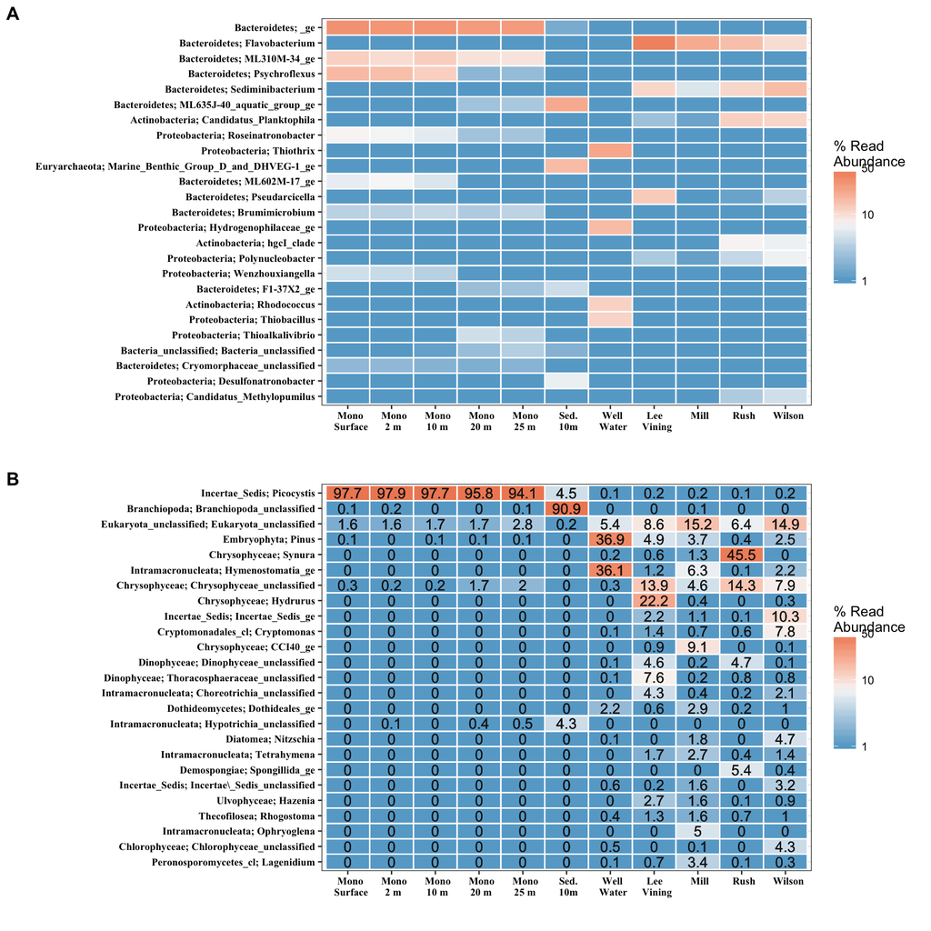